# STA6257: Homework 1 - Problem A

Mason Lowery

Last updated: 2022-07-23

### Problem A

#### Problem 1

*Plot the data and comment on relationship between insecticides (A, B, C), deposit and the proportion of killed insects*

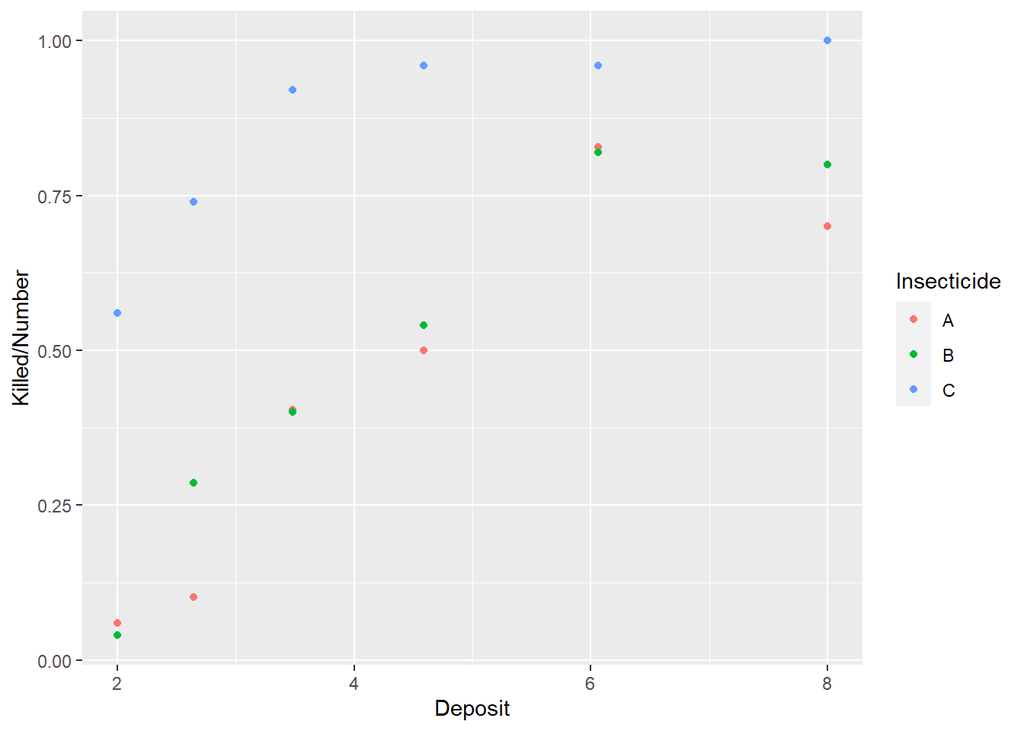

```r
data(deposit)

ggplot(data=deposit, aes(Deposit, Killed/Number, colour = Insecticide)) +
  geom_point()
```

```r
deposit$A <- ifelse(deposit$Insecticide=="A", 1, 0)
deposit$B <- ifelse(deposit$Insecticide=="B", 1, 0)
deposit$C <- ifelse(deposit$Insecticide=="C", 1, 0)
```

From the plot above that the number of insects killed increases as the amount of insecticide deposit increases. We also see that insecticide C kills a higher proportion of insects at every deopsit level in comparision to A and B.

#### Problem 2

*Fit a binomial regression model using the logit link function for the proportion of killed insects*

#### Model W/O Interaction

```r
bin <- glm(Killed/Number ~ Deposit + B + C, data=deposit, family=binomial(link="logit"), weights=Number)

summary(bin)
```

```
##
## Call:
## glm(formula = Killed/Number ~ Deposit + B + C, family = binomial(link = "logit"),
##     data = deposit, weights = Number)
##
## Deviance Residuals:
##     Min       1Q   Median       3Q      Max
## -2.9537  -1.4831   0.6142   1.2207   2.1547
##
## Coefficients:
##             Estimate Std. Error z value Pr(>|z|)
## (Intercept) -3.22136    0.27443 -11.739   <2e-16 ***
## Deposit      0.63168    0.05189  12.174   <2e-16 ***
## B            0.36953    0.20394   1.812     0.07 .
## C            2.68802    0.24067  11.169   <2e-16 ***
## ---
## Signif. codes:  0 '***' 0.001 '**' 0.01 '*' 0.05 '.' 0.1 ' ' 1
##
## (Dispersion parameter for binomial family taken to be 1)
##
##     Null deviance: 413.644  on 17  degrees of freedom
## Residual deviance:  48.026  on 14  degrees of freedom
## AIC: 118.22
##
## Number of Fisher Scoring iterations: 4
```

#### Problem 3

*Diagnose the model and identify if any influential observations exist*

```
## [1] 1.301603e-05
```

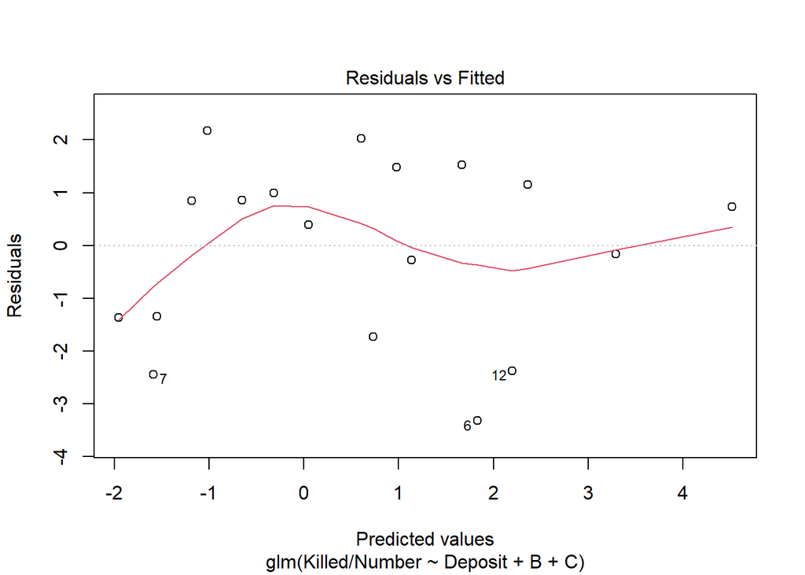

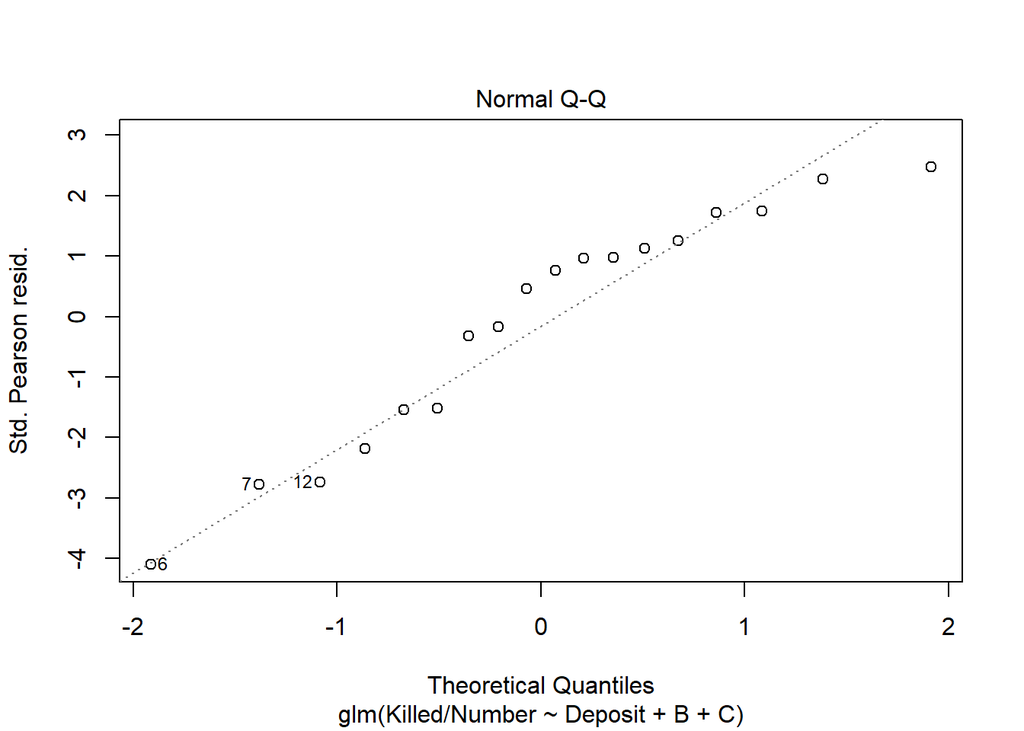

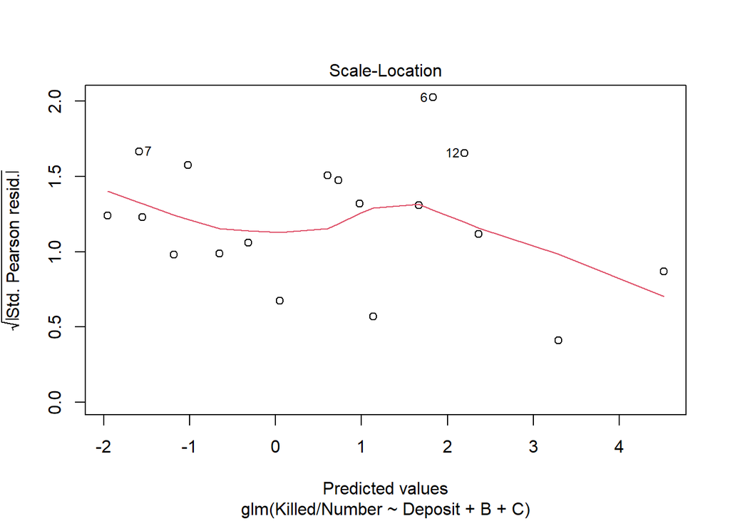

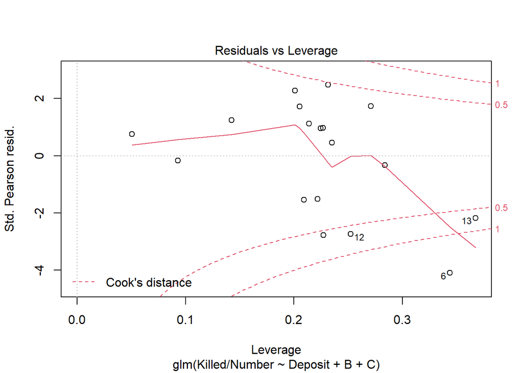

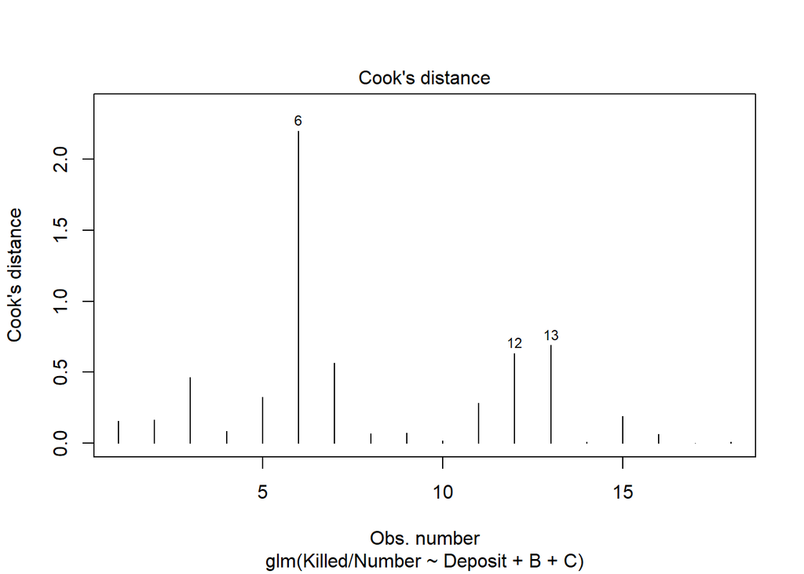

```r
plot(bin)

# Cook's distance
plot(bin, which = 4, id.n = 3)
pchisq(48.026,14,lower.tail=FALSE)
```

**Hypothesis**

$H_0:$ The Model is Adequate $H_1:$ The Model is not Adequate

**Rejection Region**

Reject $H_0$ if $p < \alpha$; $\alpha = 0.05$

We reject the null hypothesis, the output shown above indicates that the model is not adequate.

Based on the plot of Cooks Distance above, obs 6 is an extreme observation that we should consider for deletion.

#### Model with log(Deposit)

```r
bin2 <- glm(Killed/Number ~ log(Deposit) + B + C, data=deposit, family=binomial(link="logit"), weights=Number)
summary(bin2)
```

```
##
## Call:
## glm(formula = Killed/Number ~ log(Deposit) + B + C, family = binomial(link = "logit"),
##     data = deposit, weights = Number)
##
## Deviance Residuals:
##     Min       1Q   Median       3Q      Max
## -2.1388  -0.5223  -0.1143   1.0723   1.8313
##
## Coefficients:
##              Estimate Std. Error z value Pr(>|z|)
## (Intercept)   -4.4613     0.3564 -12.518   <2e-16 ***
## log(Deposit)   2.8875     0.2236  12.912   <2e-16 ***
## B              0.3489     0.2060   1.694   0.0903 .
## C              2.8402     0.2538  11.191   <2e-16 ***
## ---
## Signif. codes:  0 '***' 0.001 '**' 0.01 '*' 0.05 '.' 0.1 ' ' 1
##
## (Dispersion parameter for binomial family taken to be 1)
##
##     Null deviance: 413.644  on 17  degrees of freedom
## Residual deviance:  23.385  on 14  degrees of freedom
## AIC: 93.583
##
## Number of Fisher Scoring iterations: 4
```

#### Problem 4

*Is the Model Adequate?*

```r
pchisq(23.385,14,lower.tail=FALSE)
```

```
## [1] 0.0542864
```

**Hypothesis**

$H_0:$ The Model is Adequate $H_1:$ The Model is not Adequate

**Rejection Region**

Reject $H_0$ if $p < \alpha$; $\alpha = 0.05$

We fail to reject the null hypothesis, the output shown above indicates that the model is adequate.

#### For Fun: Model W/ Interaction

```r
bin3 <- glm(Killed/Number ~ Deposit + B + C + Deposit*B + Deposit*C, data=deposit, family=binomial(link="logit"), weights=Number)

summary(bin3)
```

```
##
## Call:
## glm(formula = Killed/Number ~ Deposit + B + C + Deposit * B +
##     Deposit * C, family = binomial(link = "logit"), data = deposit,
##     weights = Number)
##
## Deviance Residuals:
##     Min       1Q   Median       3Q      Max
## -2.9032  -1.6772   0.3543   0.9768   2.4433
##
## Coefficients:
##             Estimate Std. Error z value Pr(>|z|)
## (Intercept) -2.90282    0.36324  -7.991 1.33e-15 ***
## Deposit      0.55965    0.07487   7.475 7.74e-14 ***
## B            0.09191    0.51032   0.180   0.8571
## C            1.31766    0.67433   1.954   0.0507 .
## Deposit:B    0.06241    0.10802   0.578   0.5634
## Deposit:C    0.43252    0.20788   2.081   0.0375 *
## ---
## Signif. codes:  0 '***' 0.001 '**' 0.01 '*' 0.05 '.' 0.1 ' ' 1
##
## (Dispersion parameter for binomial family taken to be 1)
##
##     Null deviance: 413.644  on 17  degrees of freedom
## Residual deviance:  42.773  on 12  degrees of freedom
## AIC: 116.97
##
## Number of Fisher Scoring iterations: 5
```

```r
pchisq(42.773,12,lower.tail=FALSE)
```

```
## [1] 2.466773e-05
```

For fun, we see what happens if we include the interaction term. We see we have a significant interaction between Deposit and Insecticide C on a 0.05 level. However, the test for residual deviance suggests that the model is not a good fit.

#### Model W/Interaction w/ log(Deposit)

```r
bin4 <- glm(Killed/Number ~ log(Deposit) + B + C + log(Deposit)*B + log(Deposit)*C, data=deposit, family=binomial(link="logit"), weights=Number)

summary(bin4)
```

```
##
## Call:
## glm(formula = Killed/Number ~ log(Deposit) + B + C + log(Deposit) *
##     B + log(Deposit) * C, family = binomial(link = "logit"),
##     data = deposit, weights = Number)
##
## Deviance Residuals:
##     Min       1Q   Median       3Q      Max
## -1.8389  -0.9283   0.1189   0.8077   1.9701
##
## Coefficients:
##                Estimate Std. Error z value Pr(>|z|)
## (Intercept)     -4.2306     0.5239  -8.075 6.76e-16 ***
## log(Deposit)     2.7272     0.3491   7.813 5.59e-15 ***
## B                0.1878     0.7223   0.260  0.79492
## C                2.1099     0.7896   2.672  0.00754 **
## log(Deposit):B   0.1109     0.4867   0.228  0.81980
## log(Deposit):C   0.6612     0.6712   0.985  0.32462
## ---
## Signif. codes:  0 '***' 0.001 '**' 0.01 '*' 0.05 '.' 0.1 ' ' 1
##
## (Dispersion parameter for binomial family taken to be 1)
##
##     Null deviance: 413.644  on 17  degrees of freedom
## Residual deviance:  22.337  on 12  degrees of freedom
## AIC: 96.534
##
## Number of Fisher Scoring iterations: 4
```

```r
pchisq(22.337,12,lower.tail=FALSE)
```

```
## [1] 0.03391191
```

What if we take the log of the deposit variable with our model that includes the interaction term? Logging the deposit variable we have no significant interactions amongst any of our variables. Our deviance test also suggests the model is still not a good fit, 0.05>0.03, reject $H_0$. We go forward with our model first seen in problem #3.

#### Problem 6

*Use Probit and Complementary-log-log link functions to fit the model. Plot and Compare the three models using AIC*

```r
plot(Killed/Number ~ Deposit, data=deposit,
     xlab="Deposit",
     ylab="Proportion of Insects Killed")
title(main="When C=1")


bin.probit <- update( bin2, family=binomial(link="probit") )
#using link function c-log-log
bin.cll <- update( bin2, family=binomial(link="cloglog") )

# compare the different coefficient
cfs=rbind( Logistic=coef(bin2), Probit=coef(bin.probit), CLL=coef(bin.cll))
cfs
```

```
##          (Intercept) log(Deposit)         B        C
## Logistic   -4.461346     2.887499 0.3489063 2.840178
## Probit     -2.623072     1.690049 0.2085553 1.672082
## CLL        -3.138015     1.714269 0.2492542 1.706162
```

```r
cbind(cfs, Res.deviance=c(deviance(bin2), deviance(bin.probit), deviance(bin.cll)) )
```

```
##          (Intercept) log(Deposit)         B        C Res.deviance
## Logistic   -4.461346     2.887499 0.3489063 2.840178     23.38522
## Probit     -2.623072     1.690049 0.2085553 1.672082     22.34820
## CLL        -3.138015     1.714269 0.2492542 1.706162     36.46514
```

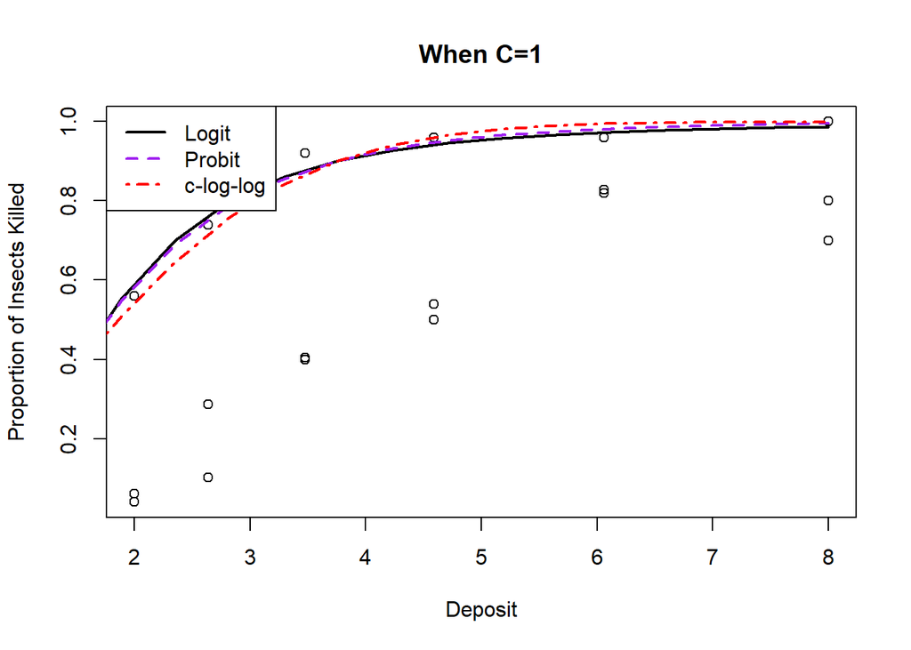

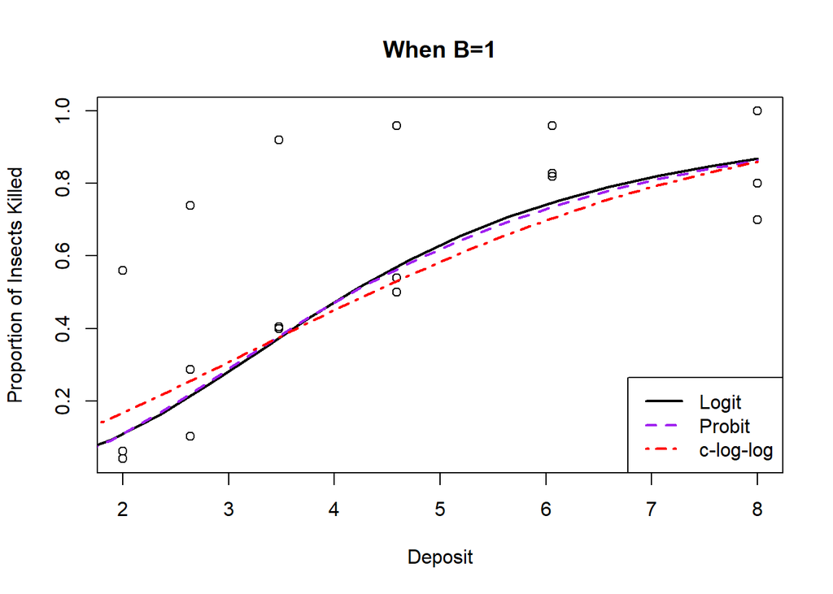

```r
# FOR C=1
b = seq(0,8,length=18)
nB = 0
nC = 1

newdata=data.frame(Deposit=b, B=nB, C=nC)


logit=predict(bin2,newdata = data.frame(Deposit=b, B=nB, C=nC),type="response")
probit=predict(bin.probit,newdata = data.frame(Deposit=b, B=nB, C=nC),type="response")
loglog=predict(bin.cll,newdata = data.frame(Deposit=b, B=nB, C=nC),type="response")


lines(logit ~ b,col="black", lwd=2)
lines(probit ~ b, col="purple",lty=2,lwd=2)
lines(loglog ~ b,col="red",lty=4,lwd=2)
legend("topleft",lwd=2,lty = c(1,2,4),col = c("black","purple","red"),legend = c("Logit","Probit","c-log-log"))

#####

# FOR B=1
b = seq(0,8,length=18)
nB = 1
nC = 0

newdata=data.frame(Deposit=b, B=nB, C=nC)


logit2=predict(bin2,newdata = data.frame(Deposit=b, B=nB, C=nC),type="response")
probit2=predict(bin.probit,newdata = data.frame(Deposit=b, B=nB, C=nC),type="response")
loglog2=predict(bin.cll,newdata = data.frame(Deposit=b, B=nB, C=nC),type="response")


plot(Killed/Number ~ Deposit, data=deposit,
     main="When B=1",
     xlab="Deposit",
     ylab="Proportion of Insects Killed")
lines(logit2 ~ b,col="black", lwd=2)
lines(probit2 ~ b, col="purple",lty=2,lwd=2)
lines(loglog2 ~ b,col="red",lty=4,lwd=2)
legend("bottomright",lwd=2,lty = c(1,2,4),col = c("black","purple","red"),legend = c("Logit","Probit","c-log-log"))
```

Above we have the graphs of our logit, probit, complementary log log functions for Insecticide B and Insecticide C. We can see for all three different functions they follow similar paths with slight deviation. We also C kills a higher amount of insects, regardless of deposit level. This accurately reflects what we saw previously.

```r
AIC(bin2)
```

```
## [1] 93.58276
```

```r
AIC(bin.probit)
```

```
## [1] 92.54574
```

```r
AIC(bin.cll)
```

```
## [1] 106.6627
```

From the output above, we see that model using the probit link function produces a slightly smaller AIC value in comparison to logit and complementary log-log, suggesting that it is a slightly better fit.

### Problem C

#### Problem 1

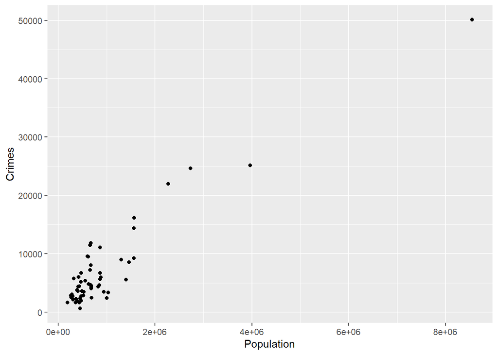

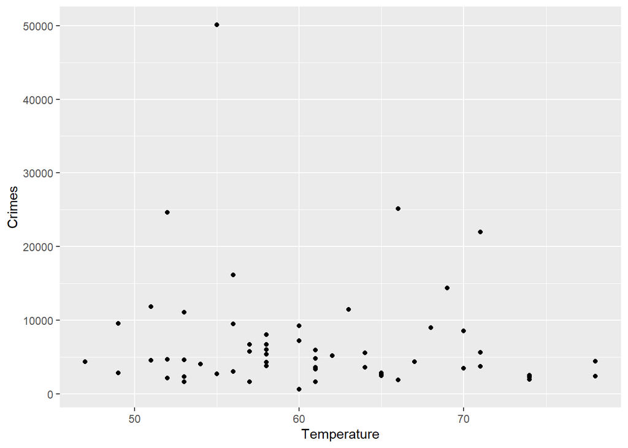

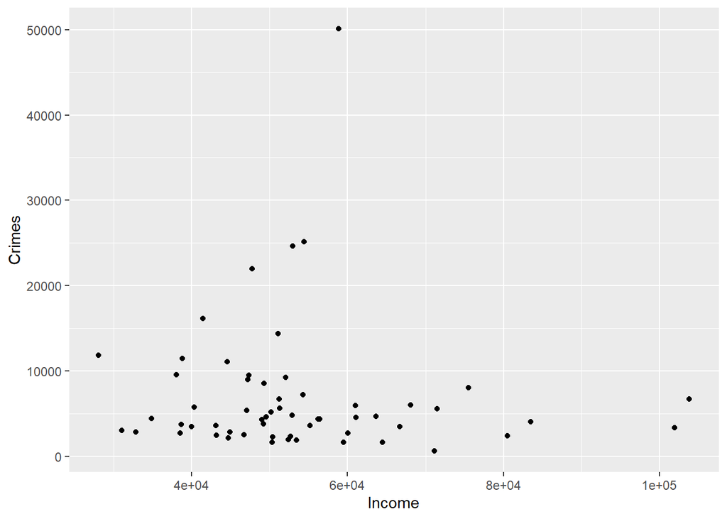

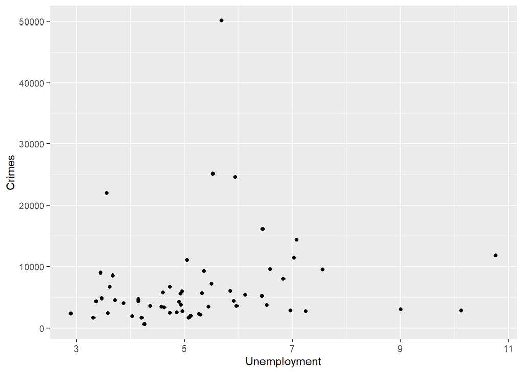

```r
crimes2015 =read.csv("https://pages.uwf.edu/acohen/teaching/datasets/crimes2015.csv")

ggplot(data=crimes2015, aes(Population, Crimes)) +
  geom_point()

ggplot(data=crimes2015, aes(Temperature, Crimes)) +
  geom_point()

ggplot(data=crimes2015, aes(Income, Crimes)) +
  geom_point()

ggplot(data=crimes2015, aes(Unemployment, Crimes)) +
  geom_point()
```

#### Problem 2-3

*Fit and compare the Poisson, quasi-Poisson, and negative binomial models*

**Note: Problem 2 and 3 have been combined for continuity in the RMD html output**

#### Poisson Model

```r
pois=glm(Crimes ~ Temperature + Income + Unemployment + Population,
           data=crimes2015,
           family = poisson(link = "log") )
summary(pois)
```

```
##
## Call:
## glm(formula = Crimes ~ Temperature + Income + Unemployment +
##     Population, family = poisson(link = "log"), data = crimes2015)
##
## Deviance Residuals:
##     Min       1Q   Median       3Q      Max
## -69.170  -39.699   -8.428   19.936  123.670
##
## Coefficients:
##                Estimate Std. Error z value Pr(>|z|)
## (Intercept)   8.786e+00  1.854e-02  473.79   <2e-16 ***
## Temperature  -3.728e-03  2.241e-04  -16.63   <2e-16 ***
## Income       -8.553e-06  1.439e-07  -59.41   <2e-16 ***
## Unemployment  5.875e-02  1.140e-03   51.52   <2e-16 ***
## Population    3.116e-07  5.818e-10  535.59   <2e-16 ***
## ---
## Signif. codes:  0 '***' 0.001 '**' 0.01 '*' 0.05 '.' 0.1 ' ' 1
##
## (Dispersion parameter for poisson family taken to be 1)
##
##     Null deviance: 315032  on 57  degrees of freedom
## Residual deviance: 105107  on 53  degrees of freedom
## AIC: 105716
##
## Number of Fisher Scoring iterations: 5
```

```
## [1] 0
```

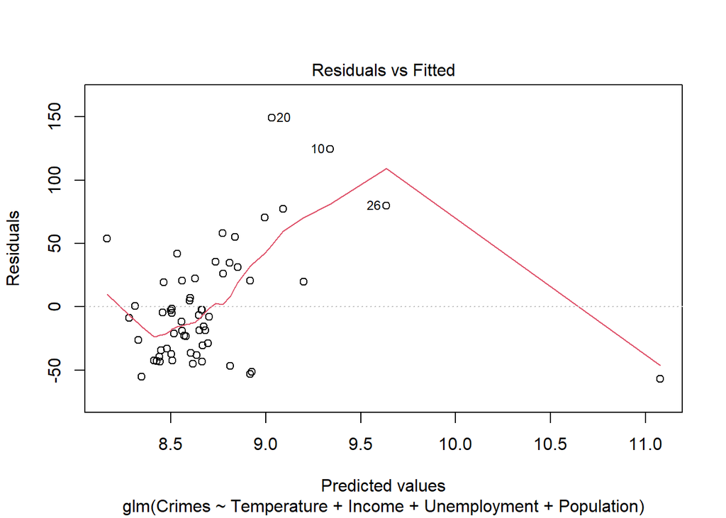

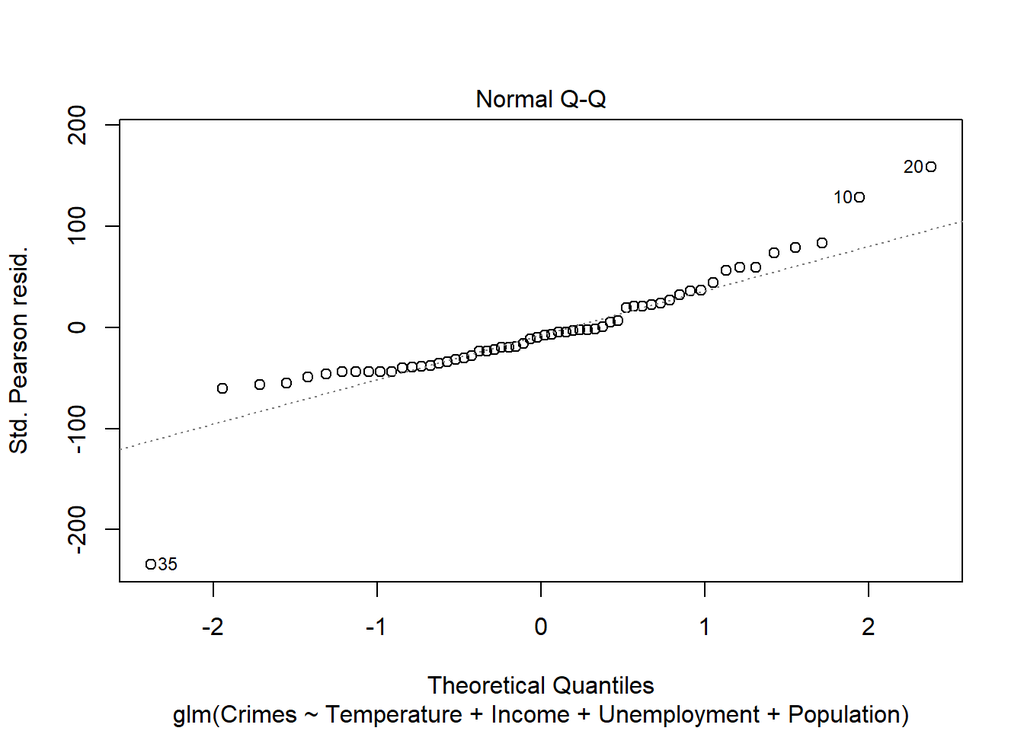

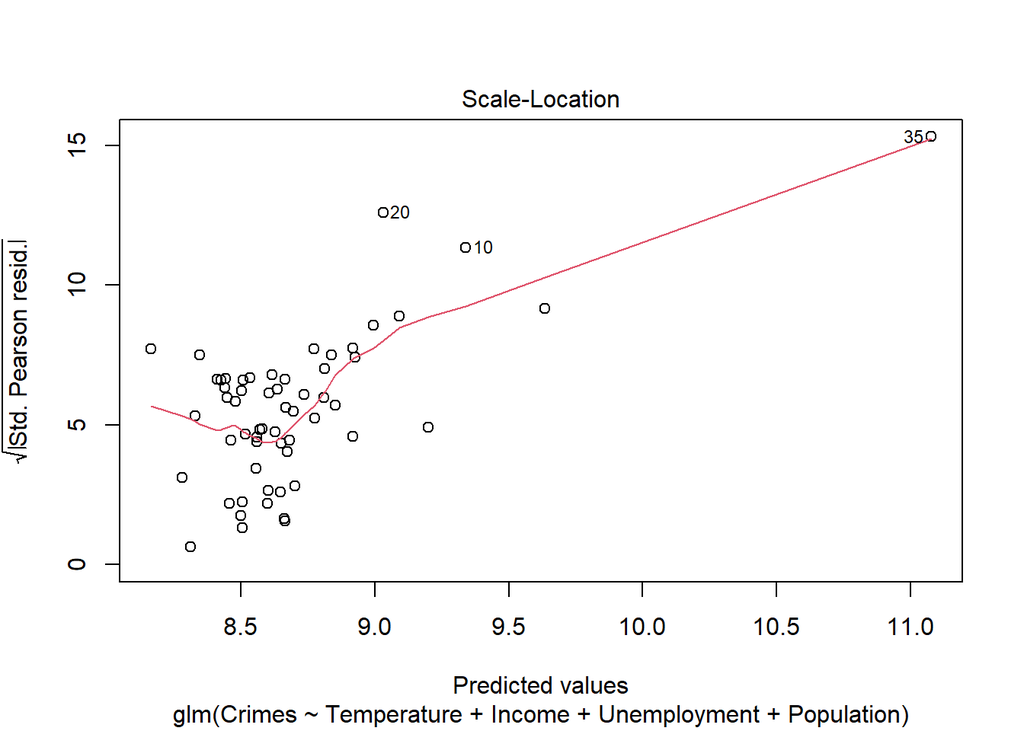

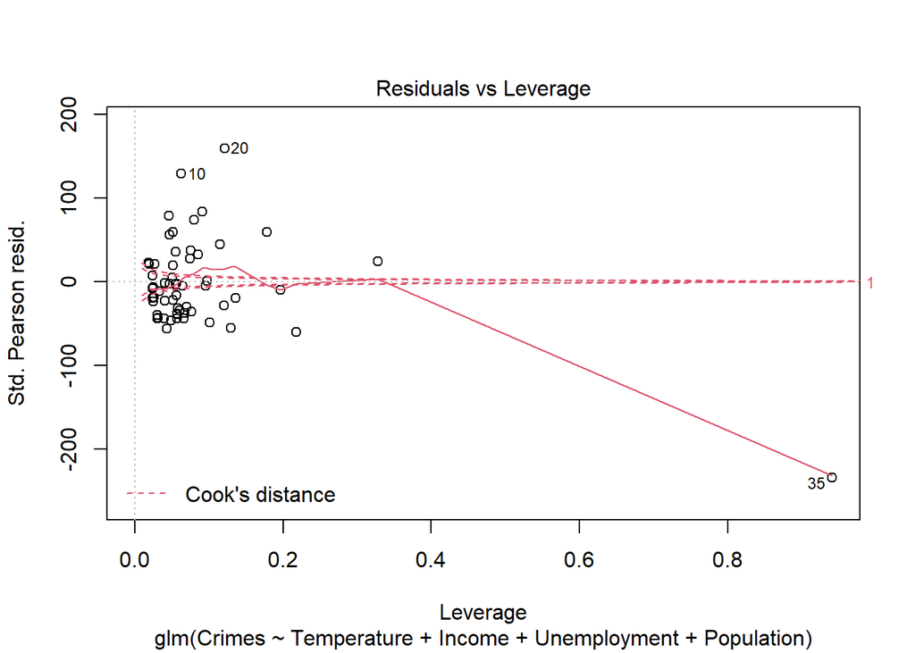

```r
#fit diagnostics
plot(pois)

#deviance
pchisq(105107,df = 53,lower.tail = FALSE)
```

#### Quasi Poisson Model

```r
quaspois = glm(Crimes ~ Temperature + Income + Unemployment + Population,
            data=crimes2015,
            family = quasipoisson(link = "log"))
summary(quaspois)
```

```
##
## Call:
## glm(formula = Crimes ~ Temperature + Income + Unemployment +
##     Population, family = quasipoisson(link = "log"), data = crimes2015)
##
## Deviance Residuals:
##     Min       1Q   Median       3Q      Max
## -69.170  -39.699   -8.428   19.936  123.670
##
## Coefficients:
##                Estimate Std. Error t value Pr(>|t|)
## (Intercept)   8.786e+00  8.502e-01  10.334 2.64e-14 ***
## Temperature  -3.728e-03  1.028e-02  -0.363    0.718
## Income       -8.553e-06  6.600e-06  -1.296    0.201
## Unemployment  5.875e-02  5.229e-02   1.124    0.266
## Population    3.116e-07  2.667e-08  11.681 2.79e-16 ***
## ---
## Signif. codes:  0 '***' 0.001 '**' 0.01 '*' 0.05 '.' 0.1 ' ' 1
##
## (Dispersion parameter for quasipoisson family taken to be 2102.16)
##
##     Null deviance: 315032  on 57  degrees of freedom
## Residual deviance: 105107  on 53  degrees of freedom
## AIC: NA
##
## Number of Fisher Scoring iterations: 5
```

```
## [1] 0
```

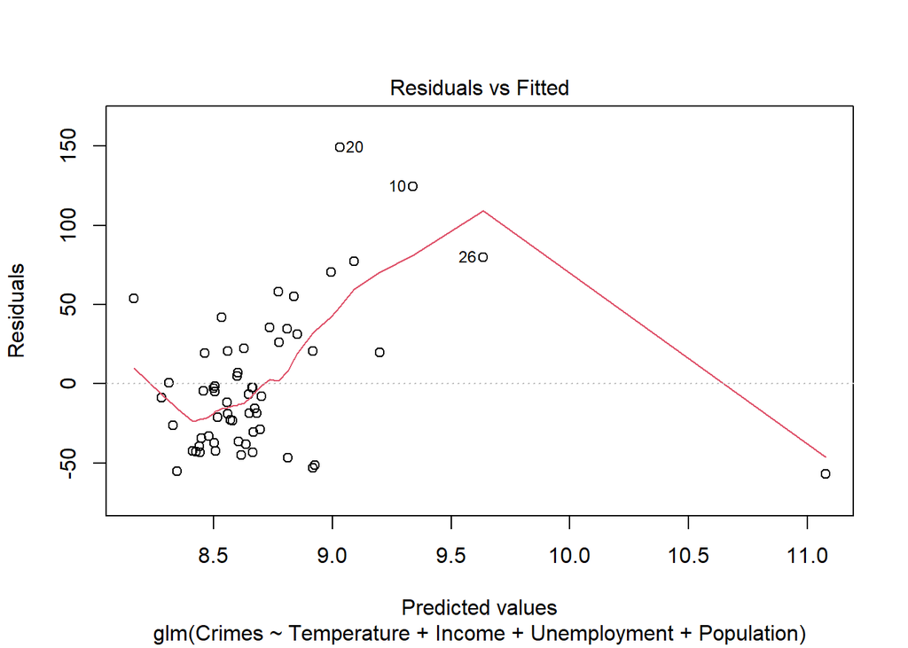

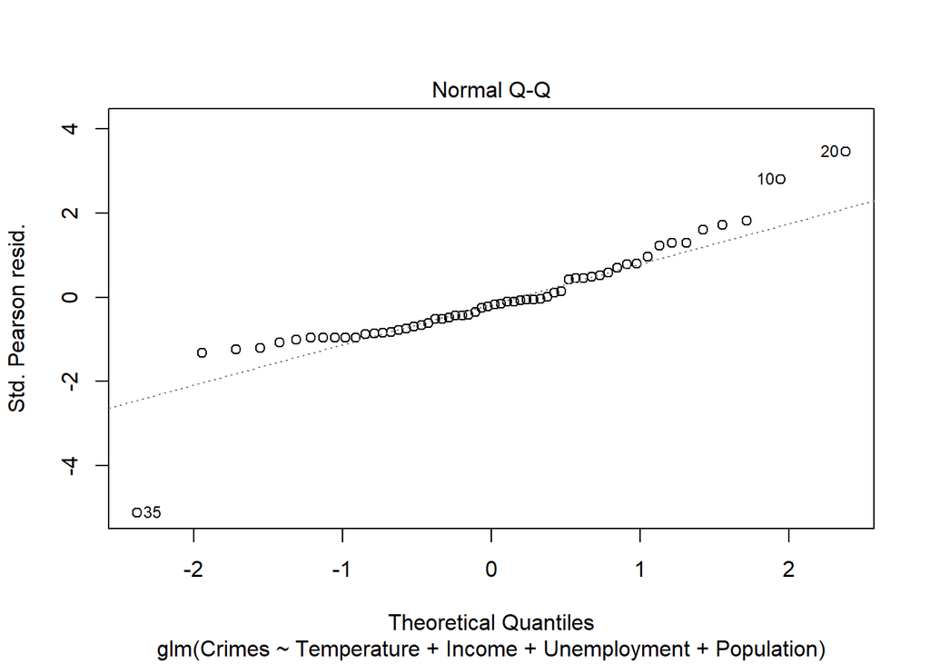

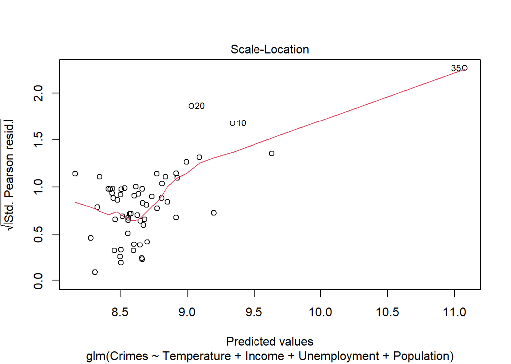

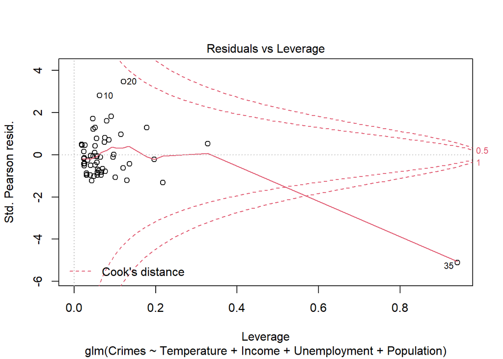

```r
#fit diagnostics
plot(quaspois)

#deviance
pchisq(quaspois$deviance, df=quaspois$df.residual, lower.tail=FALSE)
```

#### Negative Binomial Model

```r
negbin <- glm.nb(Crimes ~ Temperature + Income + Unemployment + Population, data=crimes2015)
summary(negbin)
```

```
##
## Call:
## glm.nb(formula = Crimes ~ Temperature + Income + Unemployment +
##     Population, data = crimes2015, init.theta = 4.055109533,
##     link = log)
##
## Deviance Residuals:
##     Min       1Q   Median       3Q      Max
## -3.0232  -0.9191  -0.1076   0.6911   2.0527
##
## Coefficients:
##                Estimate Std. Error z value Pr(>|z|)
## (Intercept)   8.762e+00  6.852e-01  12.788   <2e-16 ***
## Temperature  -1.237e-02  8.562e-03  -1.444   0.1487
## Income       -5.803e-06  4.914e-06  -1.181   0.2377
## Unemployment  8.331e-02  4.579e-02   1.819   0.0689 .
## Population    5.377e-07  5.491e-08   9.791   <2e-16 ***
## ---
## Signif. codes:  0 '***' 0.001 '**' 0.01 '*' 0.05 '.' 0.1 ' ' 1
##
## (Dispersion parameter for Negative Binomial(4.0551) family taken to be 1)
##
##     Null deviance: 162.915  on 57  degrees of freedom
## Residual deviance:  60.364  on 53  degrees of freedom
## AIC: 1086.7
##
## Number of Fisher Scoring iterations: 1
##
##
##               Theta:  4.055
##           Std. Err.:  0.725
##
##  2 x log-likelihood:  -1074.707
```

```
## [1] 0.2270274
```

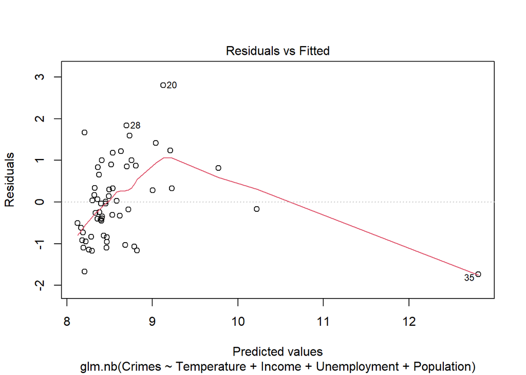

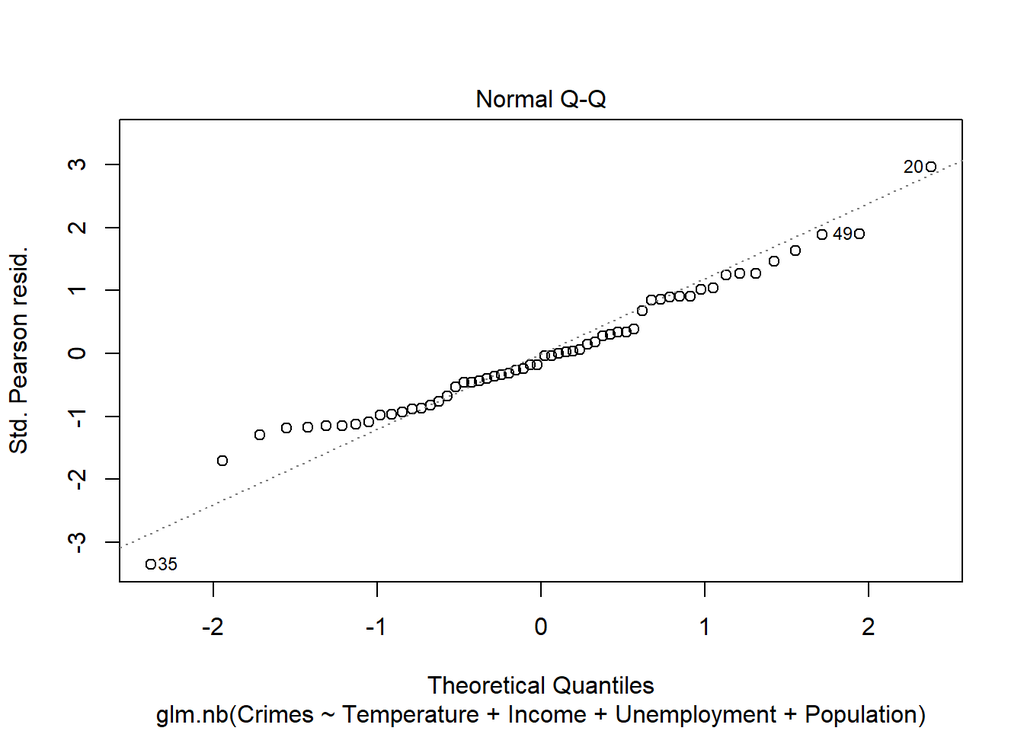

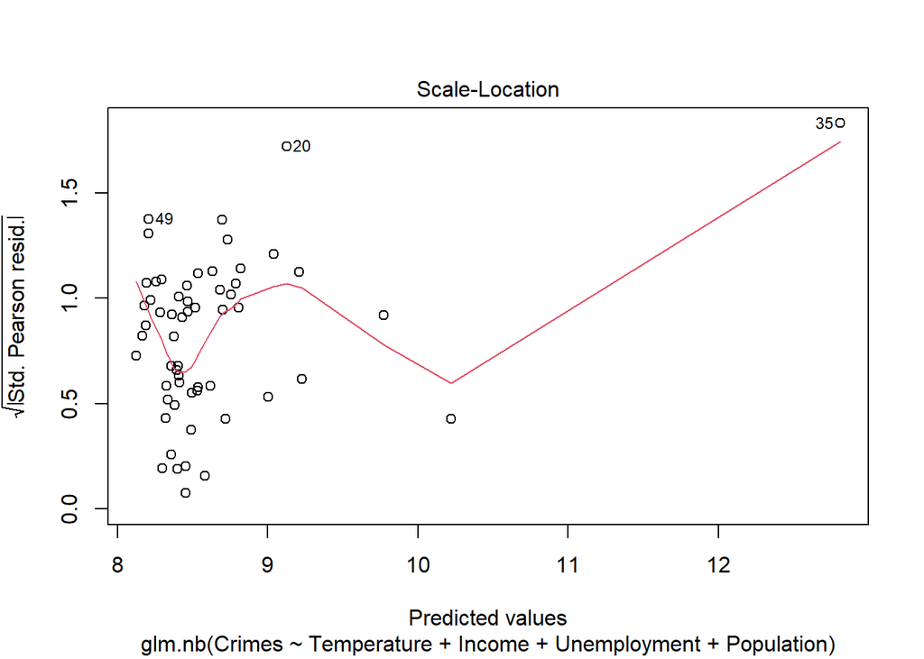

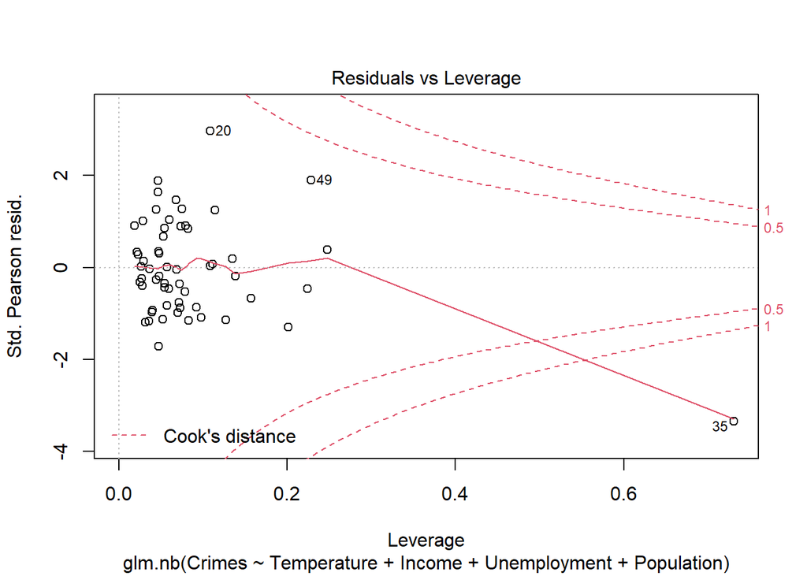

```r
#fit diagnostics
plot(negbin)

#deviance
pchisq(60.364,df = 53,lower.tail = FALSE)
```

#### Problem 4

*Interpret the best model*

From the outputs seen in problem 3, we can conclude that our negative binomial model is the best, based on it’s low AIC value and $p>\alpha$ for the residual deviance test. We can conclude that our model is adequate.

Our negative binomial regression model with coefficients can be seen below:

${\hat{Crimes} = 8.762 - 0.0123595*Temp - 0.00000580*Income + 0.0833089*Unemployment + 0.0000005*Population}$